# Determining Graduation Rate Using Regression Analysis

### 1.3 Further Data Exploration

To visualise the distribution of some of the costs incured by the Universities, we will use Histogram Plots. We do the same to see the distribution of Out of State Tuition.

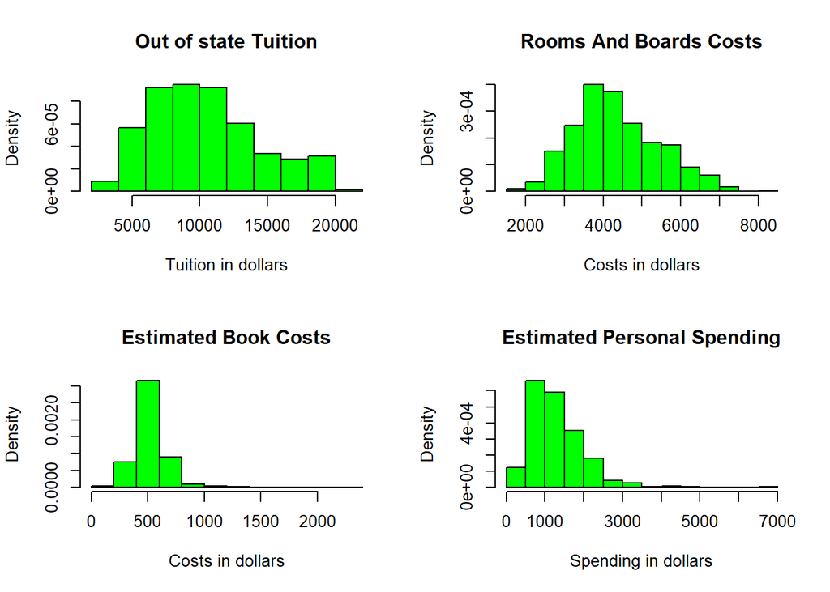

```r
par(mfrow=c(2,2))
#Plot the histogram for Outstate, Room Board, Books, and Personal
hist(mynewdata$Outstate, main = "Out of state Tuition", xlab = "Tuition in dollars", col = "green", freq = FALSE)
hist(mynewdata$Room.Board, main = "Rooms And Boards Costs", xlab = "Costs in dollars", col = "green", freq = FALSE)
hist(mynewdata$Books, main = "Estimated Book Costs", xlab = "Costs in dollars", col = "green", freq = FALSE)
hist(mynewdata$Personal, main = "Estimated Personal Spending", xlab = "Spending in dollars", col = "green", freq = FALSE)
```

## 2 Data Analysis and Linear Regression

For our dataset and analysis, the outcome is Graduation Rate represented as “Grad.Rate”, and we will be performing analysis to see how the remaining variables are significant in explaining the Graduation Rate.

### 2.1 Linear Regression Fitting with “Private” and “Elite” as Predictors

```r
myfit.private.elite<-lm(Grad.Rate~Private+Elite,data = mynewdata)

#summarizing the linear regression fit
summary(myfit.private.elite)
```

```
##
## Call:
## lm(formula = Grad.Rate ~ Private + Elite, data = mynewdata)
##
## Residuals:
##     Min      1Q  Median      3Q     Max
## -51.697 -10.126   0.764  10.764  44.764
##
## Coefficients:
##             Estimate Std. Error t value Pr(>|t|)
## (Intercept)   55.236      1.132  48.795   <2e-16 ***
## PrivateYes    11.462      1.320   8.682   <2e-16 ***
## EliteYes      18.392      1.914   9.607   <2e-16 ***
## ---
## Signif. codes:  0 '***' 0.001 '**' 0.01 '*' 0.05 '.' 0.1 ' ' 1
##
## Residual standard error: 15.43 on 697 degrees of freedom
## Multiple R-squared:  0.2073, Adjusted R-squared:  0.205
## F-statistic: 91.12 on 2 and 697 DF,  p-value: < 2.2e-16
```

#### **Analysis of the Linear Regression Fit**

- **Coefficients and Significance Significance**
  - p-value for both Private(Yes) and Elite(Yes) is *<2e-16* which shows that the predictors we used for this model are both very significant.
  - intercept is also significant with a p-value of *<2e-16*.
- **Adjusted R-squared**
  - 20.5 percent of the variability of Graduation Rate can be explained by our current model which only has Private and Elite Status as predictors.
- **p-value of F-statistic**
  - The F-statistic also has a low p value *<2.2e-16*, which shows that one of the predictors is significant in predicting the Grad.Rate.In this case, we reject the Null hypothesis.

### 2.2(a) Confidence Intervals for above coefficients

```r
#get confidence interval for the coefficient estimates
confint(myfit.private.elite)
```

```
##                 2.5 %   97.5 %
## (Intercept) 53.013095 57.45811
## PrivateYes   8.869934 14.05368
## EliteYes    14.633541 22.15086
```

### 2.2(b) Predictiction Interval of Grad Rate with Private = “Yes” and Elite= “No”

```r
#get prediction interval of Grad Rate for a new data with Private = "Yes" and Elite = "No"
predict(myfit.private.elite, newdata = data.frame(Private = "Yes", Elite="No"), interval = "prediction")
```

```
##        fit      lwr      upr
## 1 66.69741 36.36909 97.02574
```